# Extended War Report

2026-06-26

# Overview

This is an extended war report for the war **43771** between **Iron Rose Cartel** and **Torn Community Garden**. Data is presented from the side of **Torn Community Garden**. Link to the official war report can be found [HERE](https://www.torn.com/war.php?step=rankreport&rankID=43771).

## Rewards

War outcome for your faction: **Loss**  
Total hits done: **1702**  
War hits: **1014**  
Non war hits: **688**  
Total respect earned: **12801.28**  
Members contributed: **57/71**

Rewards for your faction:

| Name | Amount | Price |
| --- | --- | --- |
| Melee Cache | 3 | 452.45 M |
| Medium Arms Cache | 2 | 401.71 M |
| Armor Cache | 2 | 598.89 M |
| Small Arms Cache | 1 | 112.02 M |

Earnings from caches: **1.57 B**  
Total earnings: **1.57 B**<sup>1</sup>

<sup>1</sup>prices are based on market value or approximate trader prices if market value is unavaliable.

## War Preparation

**NOTE**: Faction Xanax might be different from Prep Xanax due to how personal stats are calculated. In this case, Faction Xanax is more accurate.

Members who **did not stack** energy before war:

|  | Name | Prep_Xanax | Faction_Xanax | Total_Hits |
| --- | --- | --- | --- | --- |
| 1 | --fawkes-- | 0 |  | 0 |
| 2 | Anonculus | 3 | 3 | 0 |
| 3 | BlackLab | 3 | 3 | 91 |
| 4 | Blue1911 | 0 |  | 11 |
| 5 | CabbageFox | 3 |  | 0 |
| 6 | Captain_Chimkin | 0 |  | 2 |
| 7 | Ch3wie | 3 |  | 0 |
| 8 | CplJamesUSMC | 1 |  | 4 |
| 9 | D3adpool | 3 | 3 | 9 |
| 10 | FalconCY | 2 |  | 82 |

[output cut: 11 more lines]

Members who **overdosed** during war preparations (but could still have stacked):

|  | Name | Prep_Xanax | Faction_Xanax | Total_Hits |
| --- | --- | --- | --- | --- |
| 1 | Ch3wie | 3 |  | 0 |
| 2 | DreadlockDave | 5 | 4 | 10 |
| 3 | Elmoz | 4 | 3 | 12 |
| 4 | GxSlade | 6 |  | 0 |
| 5 | Thomith | 6 |  | 25 |

Members who **most likely stacked** energy before war (or just used lots of xanax):

|  | Name | Prep_Xanax | Faction_Xanax | Total_Hits |
| --- | --- | --- | --- | --- |
| 1 | -Antheia- | 7 | 7 | 32 |
| 2 | Alchemist-Ifrit | 5 | 5 | 11 |
| 3 | Anthrax132 | 5 | 4 | 1 |
| 4 | BakedBeanSoup | 5 | 3 | 1 |
| 5 | Beeeeeeeee | 7 | 6 | 9 |
| 6 | BillTheImpaler | 5 | 4 | 36 |
| 7 | Brenadryl | 7 | 8 | 25 |
| 8 | Buzzsmo | 4 | 4 | 3 |
| 9 | Chapelle | 5 | 4 | 4 |
| 10 | ClydeXxX | 4 | 2 | 34 |

[output cut: 36 more lines]

## Fighting summary

### Top 5

Top 5 by overall contribution %

| Name | Contribution |
| --- | --- |
| Supreme_ | 6.76 |
| miel | 6.64 |
| Psyp | 5.41 |
| BlackLab | 5.35 |
| Zoot | 5.23 |

Top 5 by War hits

| Name | War_Hits |
| --- | --- |
| miel | 98 |
| Psyp | 90 |
| Zoot | 88 |
| FalconCY | 82 |
| Nuit | 66 |

Top 5 by Non War hits

| Name | Non_War_Hits |
| --- | --- |
| BlackLab | 91 |
| UnicornKitty | 80 |
| Supreme_ | 49 |
| GothicBasher | 46 |
| OliverDerGamer | 40 |

Top 5 by Total hits

| Name | Total_Hits |
| --- | --- |
| Supreme_ | 115 |
| miel | 113 |
| Psyp | 92 |
| BlackLab | 91 |
| Zoot | 89 |

Top 5 by Assists

| Name | Assists |
| --- | --- |
| miel | 46 |
| ScatterBean | 34 |
| Psyp | 33 |
| Ezza | 28 |
| Alchemist-Ifrit | 28 |

Chain savers - List of people who saved the chain with less than 60 seconds remaining.

```
## [1] "Friendly chain savers:"
```

| Saver | Chain | Time remaining |
| --- | --- | --- |
| Violet | 789 | 56 |
| ClydeXxX | 761 | 46 |
| ClydeXxX | 758 | 29 |
| ClydeXxX | 757 | 33 |
| ClydeXxX | 756 | 37 |
| ClydeXxX | 755 | 32 |
| Violet | 751 | 29 |
| Violet | 750 | 29 |
| Violet | 748 | 30 |
| Violet | 747 | 28 |
| Supreme_ | 746 | 24 |
| Supreme_ | 745 | 38 |
| RipleyWolf | 744 | 17 |
| RipleyWolf | 742 | 23 |
| RipleyWolf | 741 | 47 |
| Violet | 740 | 39 |
| Supreme_ | 739 | 22 |
| Violet | 738 | 29 |
| Violet | 737 | 29 |
| Violet | 735 | 30 |
| Supreme_ | 734 | 43 |
| Violet | 733 | 28 |
| Supreme_ | 732 | 56 |
| Supreme_ | 731 | 47 |
| Supreme_ | 728 | 21 |
| UnicornKitty | 682 | 24 |
| Marika | 681 | 40 |
| Marika | 679 | 26 |
| Marika | 677 | 23 |
| Marika | 676 | 26 |

[output cut: 130 more lines]

```
## [1] "Enemy chain savers:"
```

| Saver | Chain | Time remaining |
| --- | --- | --- |
| Klash | 491 | 60 |
| Loomer8 | 461 | 21 |
| Tjioo | 448 | 41 |
| Smokeytoaster | 434 | 41 |
| ProxyWorld | 432 | 32 |
|  | 417 | 35 |
| Maximate | 389 | 48 |
|  | 384 | 28 |
| Victor_Watson | 381 | 16 |
| Loomer8 | 369 | 58 |
| Victor_Watson | 363 | 58 |
| Loomer8 | 355 | 25 |
| Victor_Watson | 346 | 54 |
| Tjioo | 330 | 7 |
| CrimsonCobra | 324 | 26 |
|  | 319 | 46 |
| Hickster88 | 309 | 60 |
| Victor_Watson | 305 | 54 |
| CrimsonCobra | 303 | 13 |
|  | 295 | 5 |
| RhynoVyper | 295 | 19 |
| ProxyWorld | 294 | 41 |
| ProxyWorld | 293 | 56 |
| Smelly-Boner | 275 | 46 |
|  | 272 | 45 |
| Wiscacho | 267 | 3 |
| Elvesnator | 267 | 57 |
|  | 255 | 14 |
| Marcsontilt | 251 | 35 |
|  | 246 | 34 |
|  | 245 | 11 |
| Inexorable | 216 | 34 |
|  | 182 | 42 |
| Lovat | 166 | 15 |
|  | 166 | 39 |
| Vernster | 148 | 40 |
|  | 144 | 15 |
|  | 140 | 30 |
| Automail | 125 | 42 |
| Prod | 122 | 1 |
| Tjioo | 122 | 13 |
|  | 117 | 48 |
|  | 115 | 41 |
| Klash | 113 | 57 |
|  | 111 | 28 |
|  | 109 | 4 |
| Wildthg | 109 | 48 |
|  | 106 | 48 |
| Loomer8 | 101 | 58 |
| Automail | 99 | 7 |
| Inexorable | 98 | 25 |
|  | 92 | 50 |
|  | 91 | 6 |
| Maximate | 83 | 50 |
| Gilligan | 70 | 55 |
|  | 57 | 57 |
|  | 46 | 16 |
|  | 43 | 3 |

### Visual summary

Only including members with non-zero contribution

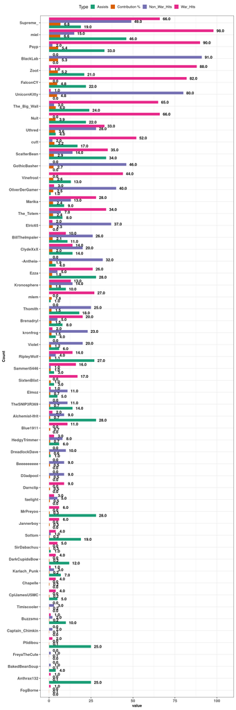

### Respect

Respect earned by each member.<sup>1</sup>  
Total respect earned: **12801.28**  
Total respect lost: **4779.81**  
Net respect change: **8021.47**<sup>2</sup>  
Average respect earned per attack: **6.8**

<sup>1</sup>Chain bonuses are ignored in per-member contributions.  
<sup>2</sup>Respect lost will be 0 if using non-faction API key.

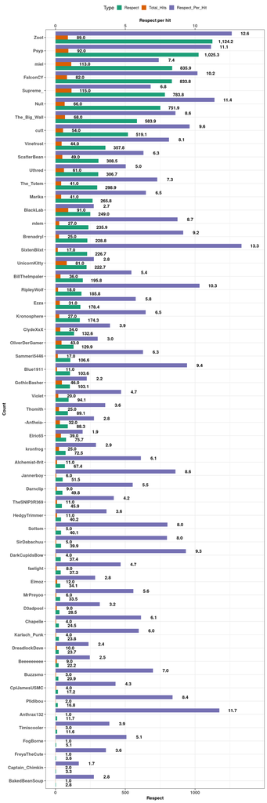

### War Score

Looking at war score gained and lost by each member.  
**The calculations IGNORE chain bonuses in order to better reflect actual contribution rather than landing a lucky hit**  
Total score earned: **9547**  
Total score lost: **16961.98**<sup>1</sup>  
Median net score per member: **-116.09**<sup>2</sup>

<sup>1</sup>Score lost will be 0 if using non-faction API key.  
<sup>2</sup>Using median instead of mean to avoid extreme values skewing the metric.

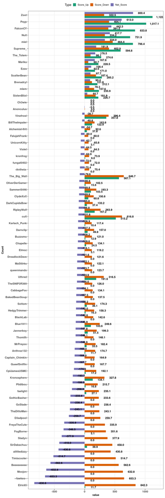

### Slackers

Members who did not meet 1% contribution cutoff

| Name | Contribution |
| --- | --- |
| Elmoz | 0.71 |
| HedgyTrimmer | 0.65 |
| Blue1911 | 0.65 |
| Alchemist-Ifrit | 0.65 |
| TheSNIP3R369 | 0.65 |
| DreadlockDave | 0.59 |
| Darnclip | 0.53 |
| D3adpool | 0.53 |
| Beeeeeeeee | 0.53 |
| faelight | 0.47 |
| Jannerboy | 0.35 |
| MrPreyoo | 0.35 |
| SirDabachuu | 0.29 |
| Sottom | 0.29 |
| CplJamesUSMC | 0.24 |
| Chapelle | 0.24 |
| Karlach_Punk | 0.24 |
| DarkCupidsBow | 0.24 |
| Buzzsmo | 0.18 |
| Timiscooler | 0.18 |
| Ptidibou | 0.12 |
| Captain_Chimkin | 0.12 |
| FogBorne | 0.06 |
| Anthrax132 | 0.06 |
| BakedBeanSoup | 0.06 |
| FreyaTheCute | 0.06 |
| Ch3wie | 0.00 |
| queenmands | 0.00 |
| MaSt0rks | 0.00 |
| alittledizzy | 0.00 |
| FalujahFrank | 0.00 |
| ThaDittoMan | 0.00 |
| CabbageFox | 0.00 |
| Sladyn | 0.00 |
| Moojon | 0.00 |
| GxSlade | 0.00 |
| –fawkes– | 0.00 |
| fungal0402 | 0.00 |
| QueefSniffin | 0.00 |
| Anonculus | 0.00 |

### Energy

Summary of who wasted the most energy and who cost the enemy the most energy.  
Calculated by adding up Losses (and Stalemates, Defends, Escapes, Interrupts) and Defends, the multiplying the number by 25.  
E_Wasted means the member spent X energy on attacks that failed.  
E_Stolen means X energy was wasted by the enemy on attacking the member unsuccessfully.  
You might want to take a closer look at members with high E_Wasted values and remind them to pick fights they can win!

<sup>1</sup> These numbers will be 0 if you are using an API key WITHOUT faction access.

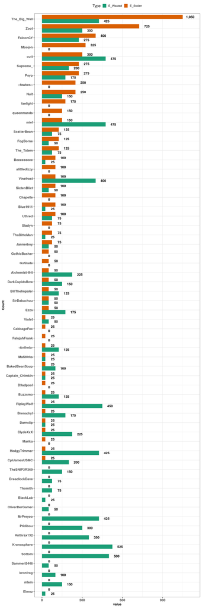

### Full table

Full table with filters and search

|  | Name | Total_Hits | Contribution | War_Hits | Non_War_Hits | Assists | Respect | Respect_Per_Hit | Respect_Lost | Score_Up | Score_Down | Net_Score |
| --- | --- | --- | --- | --- | --- | --- | --- | --- | --- | --- | --- | --- |
| 1 | faelight | 8 | 0.47 | 3 | 5 | 0 | 37.34 | 4.67 | 58.84 | 27.12 | 235.13 | -208.01 |
| 2 | CplJamesUSMC | 4 | 0.24 | 4 | 0 | 5 | 17.22 | 4.3 | 49.59 | 17.22 | 192.09 | -174.87 |
| 3 | HedgyTrimmer | 11 | 0.65 | 3 | 8 | 6 | 40.16 | 3.65 | 39.61999999999999 | 16.29 | 158.3 | -142.01 |
| 4 | Ezza | 31 | 1.82 | 26 | 5 | 28 | 178.39 | 5.75 | 16.12 | 171.01 | 62.58 | 108.43 |
| 5 | Zoot | 89 | 5.23 | 88 | 1 | 21 | 1124.2 | 12.63 | 81.78999999999999 | 1122.83 | 322.46 | 800.37 |
| 6 | The_Totem | 41 | 2.41 | 34 | 7 | 8 | 298.93 | 7.29 | 25.47 | 274.63 | 98.10000000000001 | 176.53 |
| 7 | Elric65 | 39 | 2.29 | 2 | 37 | 0 | 75.66999999999999 | 1.94 | 212.5899999999999 | 11.68 | 842.31 | -830.63 |
| 8 | Elmoz | 12 | 0.71 | 1 | 11 | 5 | 34.08000000000001 | 2.84 | 30.92 | 3.07 | 119.16 | -116.09 |
| 9 | Marika | 41 | 2.41 | 28 | 13 | 9 | 265.8 | 6.48 | 18.88 | 228.5 | 60.7 | 167.8 |
| 10 | FalconCY | 82 | 4.82 | 82 | 0 | 22 | 833.8000000000003 | 10.17 | 97.89999999999999 | 833.8000000000003 | 391.4999999999999 | 442.3 |

[output cut: 61 more lines]

## Extra details

### Xanax and refill usage

Xanax and Energy refill usage during the war.

Total Xanax used: **315**  
Xanax costs: **266.45 M**  
Total Refills used: **80**  
Refill costs: **61.84 M**

Drug cost in plot is in millions.

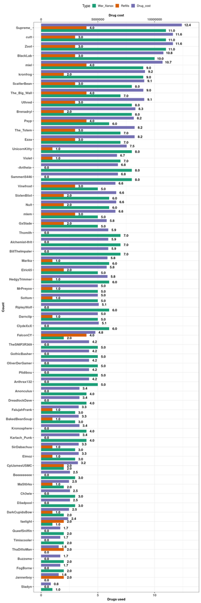

### Booster and can usage

Energy can and Booster usage during the war.

Total Boosters used: **32**  
Booster costs: **422.91 M**  
Total Cans used: **85**  
Can costs: **159.16 M**

All Boosters are assumed to be FHCs and Can price is set to average market value for ALL cans.

Booster cost in plot is in 10s of millions.

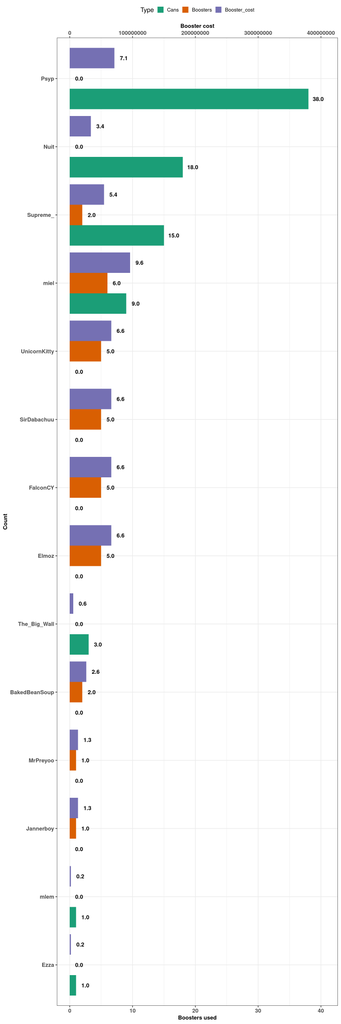

### Armory usage (BETA)

This is a summary of Armory usage during the preparation and war period.  
It can be useful for getting a good idea of how much consumables were used during the war in total.

<sup>1</sup> This section will be empty if you are using an API key WITHOUT faction access.

#### During preparation

```
## [1] "Preparation Armory usage:"
```

|  | Name | ID | action | amount | item | Hours_to_war |
| --- | --- | --- | --- | --- | --- | --- |
| 1 | BlackLab | 4012506 | used | 1 | Bottle of Beer | 71.9 |
| 2 | BlackLab | 4012506 | used | 1 | Bottle of Beer | 71.9 |
| 3 | BlackLab | 4012506 | used | 1 | Bottle of Beer | 71.89 |
| 4 | BlackLab | 4012506 | used | 1 | Bottle of Beer | 71.89 |
| 5 | BlackLab | 4012506 | used | 1 | Bottle of Beer | 71.89 |
| 6 | BlackLab | 4012506 | used | 1 | Bottle of Beer | 71.87 |
| 7 | Ch3wie | 3586526 | used | 1 | Blood Bag : A- | 71.59 |
| 8 | Ch3wie | 3586526 | used | 1 | Blood Bag : A- | 71.59 |
| 9 | Vinefrost | 2969205 | used | 1 | Xanax | 71.57 |
| 10 | BakedBeanSoup | 4199880 | used | 1 | Bottle of Beer | 71.49 |

[output cut: 890 more lines]

```
## [1] "Preparation usage totals:"
```

|  | Action | Item | Count |
| --- | --- | --- | --- |
| 1 | used | Bottle of Beer | 399 |
| 2 | loaned | Flash Grenade | 300 |
| 3 | used | Xanax | 214 |
| 4 | loaned | Smoke Grenade | 195 |
| 5 | used | Bag of Chocolate Kisses | 158 |
| 6 | loaned | Tear Gas | 100 |
| 7 | used | Points | 90 |
| 8 | loaned | Pepper Spray | 30 |
| 9 | used | Blood Bag : O+ | 21 |
| 10 | used | Blood Bag : A+ | 15 |

[output cut: 21 more lines]

```
## [1] "Only showing consumables"
```

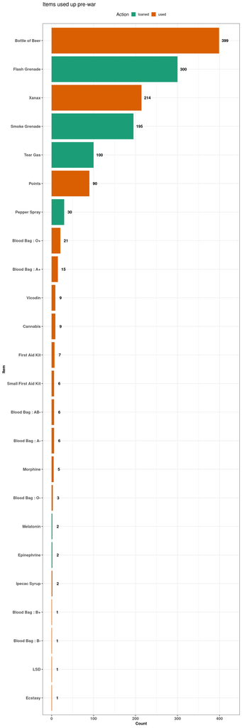

#### During war

```
## [1] "War Armory usage:"
```

|  | Name | ID | action | amount | item | Hours_to_end |
| --- | --- | --- | --- | --- | --- | --- |
| 1 | Zoot | 1759387 | used | 1 | Blood Bag : A- | 53.04 |
| 2 | Alchemist-Ifrit | 3980352 | used | 1 | Blood Bag : A+ | 53.03 |
| 3 | Alchemist-Ifrit | 3980352 | used | 1 | Blood Bag : A+ | 53.03 |
| 4 | Alchemist-Ifrit | 3980352 | used | 1 | Blood Bag : A+ | 53.03 |
| 5 | Anthrax132 | 3940834 | used | 1 | Blood Bag : O+ | 53.03 |
| 6 | Anthrax132 | 3940834 | used | 1 | Blood Bag : O+ | 53.03 |
| 7 | Anthrax132 | 3940834 | used | 1 | Blood Bag : O+ | 53.03 |
| 8 | Anthrax132 | 3940834 | used | 1 | Blood Bag : O+ | 53.03 |
| 9 | Blue1911 | 2705292 | used | 1 | Blood Bag : A- | 53.03 |
| 10 | FalconCY | 2309782 | used | 1 | Blood Bag : O+ | 53.03 |

[output cut: 1947 more lines]

```
## [1] "War usage totals:"
```

|  | Action | Item | Count |
| --- | --- | --- | --- |
| 1 | loaned | Smoke Grenade | 513 |
| 2 | used | Blood Bag : A+ | 439 |
| 3 | used | Blood Bag : O+ | 419 |
| 4 | loaned | Flash Grenade | 190 |
| 5 | used | Blood Bag : A- | 168 |
| 6 | used | Blood Bag : AB+ | 135 |
| 7 | loaned | Tear Gas | 110 |
| 8 | used | Morphine | 109 |
| 9 | used | First Aid Kit | 104 |
| 10 | used | Blood Bag : O- | 96 |

[output cut: 19 more lines]

```
## [1] "Only showing consumables"
```

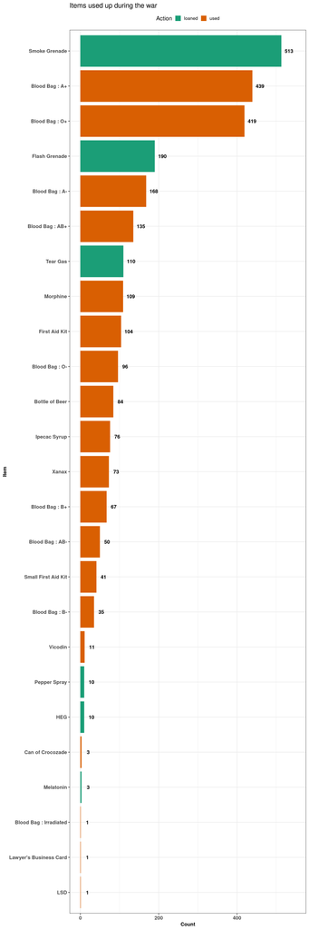

### Activity

Member activity during the war in hours.

```
## [1] "Correlation between activity and contribution:"
```

```
## [1] 0.7
```

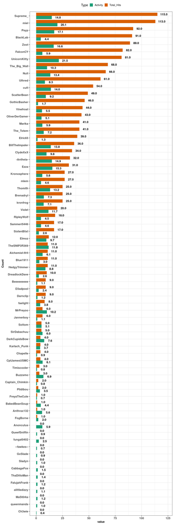

### Hospital

Summary of times hospitalized during the war

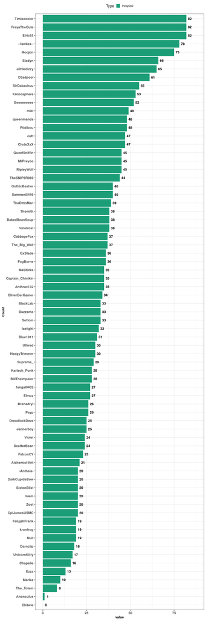

### Full table

|  | Name | War_Xanax | Refills | Boosters | Cans | Drug_cost | Booster_cost | Activity | Hospital |
| --- | --- | --- | --- | --- | --- | --- | --- | --- | --- |
| 1 | faelight | 1 | 2 | 0 | 0 | 2391880 | 0 | 3.76 | 32 |
| 2 | CplJamesUSMC | 2 | 2 | 0 | 0 | 3237760 | 0 | 6.13 | 20 |
| 3 | HedgyTrimmer | 6 | 1 | 0 | 0 | 5848280 | 0 | 8.83 | 30 |
| 4 | Ezza | 7 | 3 | 0 | 1 | 8240160 | 1872469.44 | 15.31 | 13 |
| 5 | Zoot | 11 | 3 | 0 | 0 | 11623680 | 0 | 16.65 | 20 |
| 6 | The_Totem | 7 | 3 | 0 | 0 | 8240160 | 0 | 7.18 | 8 |
| 7 | Elric65 | 5 | 2 | 0 | 0 | 5775400 | 0 | 1.31 | 82 |
| 8 | Elmoz | 3 | 1 | 5 | 0 | 3310640 | 66079855 | 9.7 | 27 |
| 9 | Marika | 6 | 1 | 0 | 0 | 5848280 | 0 | 5.91 | 10 |
| 10 | FalconCY | 2 | 4 | 5 | 0 | 4783760 | 66079855 | 5.87 | 23 |

[output cut: 61 more lines]

## AI summary (BETA)

This is an experimental portion of the report - an overview of the war generated by AI.  
When looking at this section, keep that in mind and take the results with a grain of salt.  
Before taking any actions that might impact faction members mentioned in this summary, double-check that there are no mistakes or missed key details.

## Post-War Debrief

### 1) Overall Faction Performance

The faction fielded a **large but unevenly effective roster**. Participation was broad, but a meaningful portion of members contributed little or no direct war pressure while still consuming war-time activity windows.

### 2) Team Issues & Strategic Bottlenecks

#### A. Low conversion of activity into war hits

Multiple members had respectable activity but produced little or no war pressure:

- **Moojon**: 75 hospital, near-zero output, almost no combat impact.
- **--fawkes--**: 78 hospital, 0 war hits, no meaningful offensive contribution.
- **alittledizzy, Timiscooler, Sladyn, FreyaTheCute, queenmands, QueefSniffin, MaSt0rks, BakedBeanSoup** and others showed **presence without decisive war impact**.

This suggests a faction-wide issue with:

- poor target assignment,
- lack of turn discipline,
- or members remaining active but failing to secure war-efficient actions.

#### B. Excessive energy waste

Several players burned significant energy without translating it into productive hits:

- **UnicornKitty**: 81 total hits but only 1 war hit, indicating extremely poor war prioritization despite high activity.
- **BlackLab**: 91 non-war hits, 0 war hits; large volume but no war-focused conversion.
- **CplJamesUSMC, OliverDerGamer, BillTheImpaler, Supreme_** all had notable wasted energy or inefficient hit profiles relative to their war returns.

This points to a structural problem: **energy was often spent on non-essential or low-value targets** rather than war-progress actions.

#### C. Finishing inefficiency: missing mug/leave optimization

Several members had high total hits but low war utility, implying poor finishing choices. War progress generally benefits from:

- leaving targets,
- hospitalizing at the right time,
- avoiding mugs unless tactically necessary.

Players like **BlackLab, UnicornKitty, OliverDerGamer, BillTheImpaler, DreadlockDave** appear to have contributed more to activity stats than to clean war progression.

#### D. Hospital vulnerability was widespread

A large number of members sat in hospital for extended periods:

- **Elric65, Moojon, --fawkes--, Timiscooler, FreyaTheCute, FogBorne, Captain_Chimkin, ThaDittoMan** etc.

High hospital time reduced uptime and indicates either:

- poor defensive resilience,
- enemy focus on soft targets,
- or lack of coordinated protection.

### 3) Individual Highlights: Positive Performers

Below are the most valuable contributors, based on war hits, assistance, efficiency, investment, and/or being difficult to suppress.

#### “Unbeatable” / disruptive profiles

- **Zoot**: elite **E_Stolen 725**
- **Psyp**: elite war volume and strong net gain
- **FalconCY**: high output with solid support role
- **miel**: very large contribution and strong war economy

### 4) Individual Highlights: Negative Underperformers

These members most clearly hindered the war effort through inactivity, poor efficiency, or heavy negative Net_Score.

#### Inefficient energy spenders

- **UnicornKitty**
  - **81 total hits**, but only **1 war hit**
  - Very poor war focus, despite **21.47 activity**
  - One of the most inefficient users of war time
- **BlackLab**
  - **91 non-war hits**, **0 war hits**
  - High output, wrong target class
  - Essentially converted combat energy into non-war value
- **OliverDerGamer**
  - High total engagement, but poor war conversion and negative score outcome
- **BillTheImpaler**
  - Strong activity and moderate total hits, but costly and inefficient relative to return
- **DreadlockDave**
  - Low impact with hospital time and negative efficiency

### 5) Additional Observations

#### High activity, low impact cases

A recurring issue is members with decent activity but no decisive war result:

- **GxSlade**: some activity, no offensive traction
- **alittledizzy**: present, but no hits
- **BlackLab**: active, but on the wrong target type
- **UnicornKitty**: extremely active, but war conversion was poor
- **Moojon**: almost entirely downtime with no useful output

#### Strong efficiency outliers

- **Zoot** stands out as the most dangerous offensive asset.
- **Psyp** combines high volume with strong support and investment.
- **miel** had one of the best overall war profiles in terms of raw contribution.
- **FalconCY** was highly effective and reliable.

#### Notable support value

Some players were not top in war hits but still contributed well through assists:

- **ScatterBean**
- **The_Totem**
- **Uthred**
- **Anthrax132**
- **MrPreyoo**
- **RipleyWolf**

These players helped maintain war flow and should be treated as valuable support assets.

## Bottom Line

The faction’s war was driven by a **small group of elite attackers and support players**, while a large portion of the roster either:

1. spent time in hospital,
2. failed to convert activity into war hits, or
3. burned energy on non-war targets.